# Carbon Taxes and CO2 Emissions: Sweden as a Case Study

Group Daikon

2024-03-19

This R markdown document serves as a replication code from the article “Carbon Taxes and CO2 Emissions: Sweden as a Case Study” by Julius J. Andersson from American Economic Journal: Economic Policy, 2019. It is part of a groupwork project in the scope of the Machine Learning and Causality class at ESMT Berlin. A few changes have been made to the synthetic control methods to learn about the significance of implementing different methods of SCM( eg “in-time”, “in-place” and “Leave-one-out”)

In this code we first upload the necessary libraries.

```r
library(dplyr)
```

```r
library(haven)
library(ggplot2)
library(patchwork)
library(tidyverse)
library(Synth)
 library(foreign)
library(plm)
library(lmtest)
library(sandwich)
library(AER)
library(stargazer)
```

Here we import the descriptive_data.dta dataset that includes the data on gasoline fuel tax rates and prices in Sweden and OECD countries as well as data on CO2 emissions from transport and other descriptive data.

```r
data <- read.dta("descriptive_data.dta")
```

```r
p1 <- ggplot(data, aes(x = year)) +
  geom_line(aes(y = Real_Gasoline_Price), color = "red") +
  geom_line(aes(y = Real_Carbontax), color = "blue") +
  geom_line(aes(y = Real_VAT), color = "purple") +
  geom_line(aes(y = Real_Energytax), color = "green") +
  geom_vline(xintercept = 1990, linetype = "dotted") +
  geom_label(data = subset(data, year == 1990), aes(y = Real_Gasoline_Price + 2, label = "Gasoline price"), color = "red", hjust = -0.2, size = 3) +
  geom_label(data = subset(data, year == 1995), aes(y = Real_Carbontax - 0.5, label = "Carbon tax"), color = "blue", hjust = -0.2, size = 3) +
  geom_label(data = subset(data, year == 1990), aes(y = Real_VAT +  0.5, label = "VAT"), color = "purple", hjust = -0.2, size = 3) +
  geom_label(data = subset(data, year == 1990), aes(y = Real_Energytax+1, label = "Energy tax"), color = "green", hjust = -0.2, size = 3) +
  scale_y_continuous(name = "Real price (SEK/litre)", limits = c(0, 13)) +
  scale_x_continuous(name = "Year") +
  theme_minimal() +
  labs(title = "Gasoline Price Components in Sweden 1960-2005",) +
  theme(plot.title = element_text(hjust = 0.5)) +
  scale_colour_manual(values = c("red", "blue", "purple", "green"),
                      labels = c("Gasoline price", "Carbon tax", "VAT", "Energy tax"),
                      breaks = c("Real_Gasoline_Price", "Real_Carbontax", "Real_VAT", "Real_Energytax")) +
  theme(legend.title = element_blank(),
        legend.text = element_text(size = 12),
        legend.key.size = unit(1, "cm"))
```

```r
p2 <- ggplot(data, aes(x = year)) +
  geom_line(aes(y = Real_Gasoline_Price), color = "blue") +
  geom_line(aes(y = Real_total_tax), color = "purple") +
  geom_vline(xintercept = 1990,linetype='dashed') +
  scale_y_continuous(name = "Real price (SEK/litre)", limits = c(0, 13)) +
  scale_x_continuous(name = "Year") +
  theme_minimal() +
  labs(title = "Gasoline Price and Total Tax in Sweden 1960-2005") +
  theme(plot.title = element_text(hjust = 0.5)) +
  geom_label(data = subset(data, year == 1995), aes(y = Real_Gasoline_Price+2.5, label = "Gasoline price"), color = "blue", hjust = -0.2, size = 3) +
  geom_label(data = subset(data, year == 1995), aes(y = Real_total_tax-1, label = "Total tax"), color = "purple", hjust = -0.2, size = 3)
```

```r
p3 <- p1 + p2

ggsave("figure1.png",width = 30, height = 30, units = "cm")
```

We then recreate the graph of road sector fuel consumption per capita (kg of oil equivalent). We plot the clear separation of when the VAT + carbon tax were introduced. After the introduction we can observe the reduction of gasoline consumption.

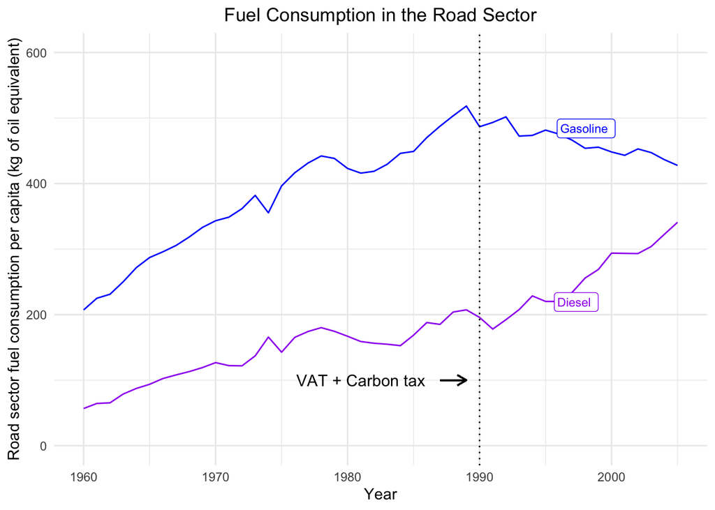

```r
ggplot(data, aes(x = year)) +
  geom_line(aes(y = gas_cons), color = "blue") +
  geom_line(aes(y = diesel_cons), color = "purple") +
  geom_vline(xintercept = 1990, linetype = "dotted", color = "black") +
  geom_segment(aes(x = 1987, y = 100, xend = 1989, yend = 100), color = "black", arrow = arrow(length = unit(0.1, "inches"))) +
  annotate("text", x = 1981, y = 100, label = "VAT + Carbon tax", size = 4) +
  scale_y_continuous(name = "Road sector fuel consumption per capita (kg of oil equivalent)", limits = c(0, 600)) +
  scale_x_continuous(name = "Year") +
  theme_minimal() +
  labs(title = "Fuel Consumption in the Road Sector") +
  theme(plot.title = element_text(hjust = 0.5)) +
  guides(color = guide_legend(title = NULL)) +
  theme(legend.title = element_blank(),
        legend.text = element_text(size = 12),
        legend.key.size = unit(1, "cm")) +
    geom_label(data = subset(data, year == 1995), aes(y = gas_cons+2.5, label = "Gasoline"), color = "blue", hjust = -0.2, size = 3) +
  geom_label(data = subset(data, year == 1995), aes(y = diesel_cons-1, label = "Diesel"), color = "purple", hjust = -0.2, size = 3)
```

```r
ggsave('figure2.jpg')
```

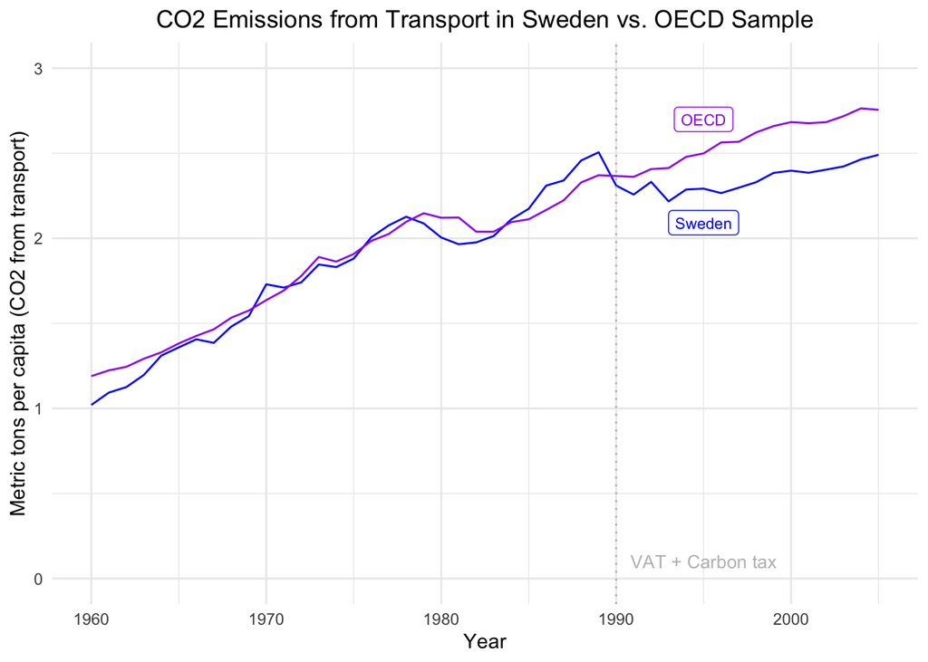

```r
ggplot(data, aes(x = year)) +
  geom_line(aes(y = CO2_Sweden), color = "blue") +
  geom_line(aes(y = CO2_OECD), color = "purple") +
  geom_vline(xintercept = 1990, linetype = "dotted",color='gray') +
  annotate("text", x = 1995, y = 0.10, label = "VAT + Carbon tax", size = 3.5, color='gray') +
  scale_y_continuous(name = "Metric tons per capita (CO2 from transport)", limits = c(0, 3)) +
  scale_x_continuous(name = "Year") +
  theme_minimal() +
  labs(title = "CO2 Emissions from Transport in Sweden vs. OECD Sample") + # Title
  theme(plot.title = element_text(hjust = 0.5)) + # Center title
  guides(color = guide_legend(title = NULL)) + # No legend title
  theme(legend.position = "bottomright") + # Legend position
  scale_color_manual(values = c("Sweden" = "blue", "OECD sample" = "red"),
                     labels = c("Sweden", "OECD sample"),
                     breaks = c("CO2_Sweden", "CO2_OECD")) +
geom_label(data = subset(data, year == 1995), aes(y = CO2_Sweden-0.2, label = "Sweden"), color = "blue", size = 3) +
geom_label(data = subset(data, year == 1995), aes(y = CO2_OECD+0.2, label = "OECD"), color = "purple", size = 3)
```

```r
ggsave('figure3.jpg')
 carbontax <- read.dta('carbontax_data.dta')
attach(carbontax)
 dataprep.out <- dataprep(foo = carbontax,
                          predictors = c("GDP_per_capita", "gas_cons_capita", "vehicles_capita",
                                         "urban_pop", "CO2_transport_capita"),
                          predictors.op = "mean",
                          time.predictors.prior = 1980:1989,
                          special.predictors = list(
                            list("CO2_transport_capita", 1989, "mean"),
                            list("CO2_transport_capita", 1980, "mean"),
                            list("CO2_transport_capita", 1970, "mean")
                          ),
                          dependent = "CO2_transport_capita",
                          unit.variable = "Countryno",
                          unit.names.variable = "country",
                          time.variable = "year",
                          treatment.identifier = 13,
                          controls.identifier = c(1:12, 14:15),
                          time.optimize.ssr = 1960:1989,
                          time.plot = 1960:2005
                          #lags = c(1)  # Introduce lag of 1 year for CO2_transport_capita
 )


 synth.out <- synth(data.prep.obj = dataprep.out,
                    method = "All")
```

```
##
## X1, X0, Z1, Z0 all come directly from dataprep object.
##
##
## ****************
##  searching for synthetic control unit
##
##
## ****************
## ****************
## ****************
##
## MSPE (LOSS V): 0.001226143
##
## solution.v:
##  0.08753413 0.01359257 0.1246882 0.09824295 0.1315124 0.1725153 0.3352087 0.03670569
##
## solution.w:
##  5.53241e-05 0.1988968 5.29468e-05 0.3813463 0.0001912454 0.09029762 3.92e-08 0.0003198407 0.1745189 0.00155282 0.0004717405 0.0004066288 0.06298805 0.08890179
```

```r
 synth.tables <- synth.tab(dataprep.res = dataprep.out,
                           synth.res = synth.out
                           )


### Table 1: CO2 Emissions From Transport Predictor Means Before Tax Reform
 synth.tables$tab.pred[1:7, ]
```

```
##                                     Treated Synthetic Sample Mean
## GDP_per_capita                    20121.479 20126.141   18706.663
## gas_cons_capita                     456.178   406.370     425.510
## vehicles_capita                     405.562   406.555     402.368
## urban_pop                            83.099    83.048      75.238
## CO2_transport_capita                  2.186     2.190       2.162
## special.CO2_transport_capita.1989     2.506     2.477       2.371
## special.CO2_transport_capita.1980     2.005     2.033       2.121
```

```r
### Table 2: Country Weights in Synthetic Sweden
 synth.tables$tab.w[1:14, ]
```

```
##    w.weights    unit.names unit.numbers
## 1      0.000     Australia            1
## 2      0.199       Belgium            2
## 3      0.000        Canada            3
## 4      0.381       Denmark            4
## 5      0.000        France            5
## 6      0.090        Greece            6
## 7      0.000       Iceland            7
## 8      0.000         Japan            8
## 9      0.175   New Zealand            9
## 10     0.002        Poland           10
## 11     0.000      Portugal           11
## 12     0.000         Spain           12
## 14     0.063   Switzerland           14
## 15     0.089 United States           15
```

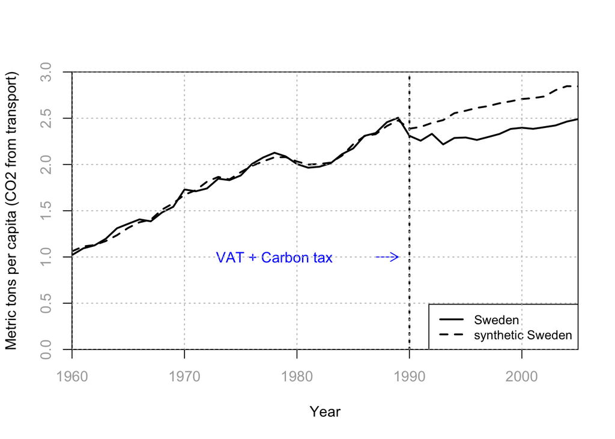

```r
### Figure 4: Path Plot of per capita CO2 Emissions from Transport

 par(col.axis = "darkgray", col.lab = "black", col.main = "black", col.sub = "black")  # Set axis, labels, title, and subtitle color to black
 par(font.main = 1, font.axis = 1, font.lab = 1, font.sub = 1)  # Set font style to bold
 par(bg = "white")
 path.plot(synth.res = synth.out,
           dataprep.res = dataprep.out,
           Ylab = "Metric tons per capita (CO2 from transport)",
           Xlab = "Year",
           Ylim = c(0,3),
           Legend = c("Sweden","synthetic Sweden"),
           Legend.position = "bottomright"
           )
# Add line
abline(v=1990,lty="dotted",lwd=2)
arrows(1987,1.0,1989,1.0,col="blue",length=.1)
Cex.set <- 1
text(1978,1.0,"VAT + Carbon tax",col="blue",cex=Cex.set)
grid(lty = "dotted", col = "gray")
```

```r
#changed colours and placeholder placement
```

Figure 5: Gap in per capita CO2 Emissions from Transport between Sweden and Synthetic Sweden

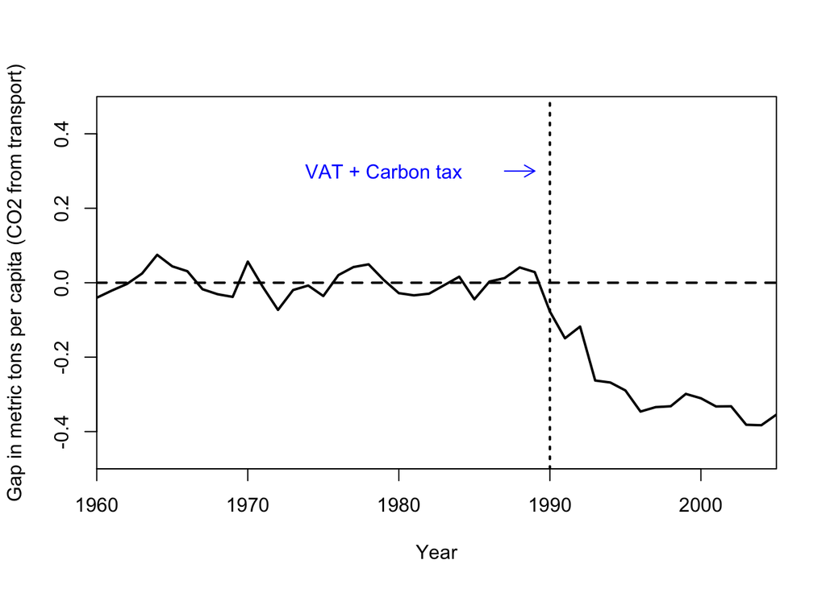

```r
 gaps.plot(synth.res = synth.out,
           dataprep.res = dataprep.out,
           Ylab = "Gap in metric tons per capita (CO2 from transport)",
           Xlab = "Year",
           Ylim = c(-0.5,0.5),
           Main = NA
           )

#Add line
abline(v=1990,lty="dotted",lwd=2)
arrows(1987,0.3,1989,0.3,col="blue",length=.1)
Cex.set <- 1
text(1979,0.3,"VAT + Carbon tax",col="blue",cex=Cex.set)
```

For the in-time tests, the year of treatment is shifted to 1970 and 1985, years that are both prior to the actual environmental tax reform. For the two tests, the choice of synthetic control is based only on data from 1960–1969 and 1960–1984, respectively. We want to find that this placebo treatment doesn’t result in a post-placebo-treatment divergence in the trajectory of emissions between Sweden and its synthetic control.

### Placebo in-time test

Placebo test in time for 1985. Observe tax effect until 2000 instead of 1990 to increase emphasis of special predictors on the outcome (C02).

```r
dataprep.out <-
  dataprep(foo = carbontax,
           predictors = c("GDP_per_capita" , "gas_cons_capita" , "vehicles_capita" ,
                          "urban_pop") ,
           predictors.op = "mean" ,
           time.predictors.prior = 1970:1984 ,
           special.predictors = list(
             list("CO2_transport_capita" , 1984 , "mean"),
             list("CO2_transport_capita" , 1975 , "mean"),
             list("CO2_transport_capita" , 1970 , "mean")
           ),
           dependent = "CO2_transport_capita",
           unit.variable = "Countryno",
           unit.names.variable = "country",
           time.variable = "year",
           treatment.identifier = 13,
           controls.identifier = c(1:12,14:15),
           time.optimize.ssr = 1960:1984,
           time.plot = 1960:2000
  )

synth.out <- synth(
  data.prep.obj = dataprep.out,
  method = "BFGS"
)
```

```
##
## X1, X0, Z1, Z0 all come directly from dataprep object.
##
##
## ****************
##  searching for synthetic control unit
##
##
## ****************
## ****************
## ****************
##
## MSPE (LOSS V): 0.001798815
##
## solution.v:
##  1e-10 0.1185538 0.1522623 0.04625177 0.1516601 0.5030691 0.02820286
##
## solution.w:
##  0.06099093 0.3671628 0.0002277895 0.2892453 0.05859245 0.0002915363 0.0007619968 0.001177888 0.004253595 0.0003557964 0.0005131206 0.000482747 0.1372791 0.07866495
```

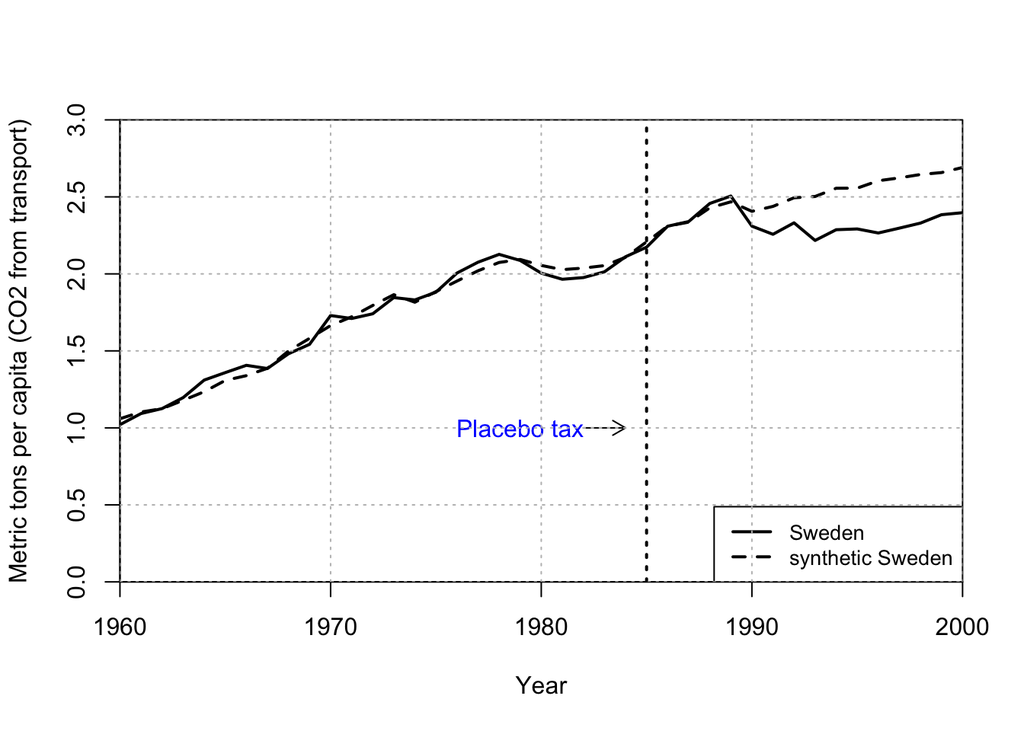

```r
#png("placebo_1985.png", width = 800, height = 600)  # Adjust width and height as needed

path.plot(synth.res = synth.out,
          dataprep.res = dataprep.out,
          Ylab = "Metric tons per capita (CO2 from transport)",
          Xlab = "Year",
          Ylim = c(0,3),
          Legend = c("Sweden","synthetic Sweden"),
          Legend.position = "bottomright"
)

# Add line
abline(v=1985,lty="dotted",lwd=2)
arrows(1982,1.0,1984,1.0,col="black",length=.1)
Cex.set <- 1
text(1979,1.0,"Placebo tax",col="blue",cex=Cex.set)
grid(lty = "dotted", col = "gray")
```

```r
#dev.off()
```

Placebo test in time for 1970 (excluding Poland due to missing GDP data 1960-69).  
By making changes in the special predictors list we can analyse the impact of additional independant variables.

We want to check if vehicles per capita has a significant impact on the outcome(increase co2) under the assumption that it is not affected by the treatment (imposing vat and carbon tax).

```r
dataprep.out <-
              dataprep(foo = carbontax,
                       predictors = c("GDP_per_capita" , "gas_cons_capita" , "vehicles_capita" ,
                                      "urban_pop") ,
                       predictors.op = "mean" ,
                       time.predictors.prior = 1960:1969 ,
                       special.predictors = list(
                         list("CO2_transport_capita" , 1960:1970 , "mean"),
                         list("vehicles_capita" , 1960:1970 , "mean")

                                   ),
                       dependent = "CO2_transport_capita",
                       unit.variable = "Countryno",
                       unit.names.variable = "country",
                       time.variable = "year",
                       treatment.identifier = 13,
                       controls.identifier = c(1:9, 11:12, 14:15),
                       time.optimize.ssr = 1960:1969,
                       time.plot = 1960:1990
                       )

synth.out <- synth(
                   data.prep.obj = dataprep.out,
                   method = "All"
                   )
```

```
##
## X1, X0, Z1, Z0 all come directly from dataprep object.
##
##
## ****************
##  searching for synthetic control unit
##
##
## ****************
## ****************
## ****************
##
## MSPE (LOSS V): 0.00102493
##
## solution.v:
##  0.1836734 0.2394972 0.003750018 0.18924 0.07335435 0.310485
##
## solution.w:
##  0.1798275 0.1016326 0.001483411 0.3431323 0.1369183 0.003028324 0.00543524 0.00323183 0.1450586 0.003200431 0.003567901 0.07282181 0.0006617284
```

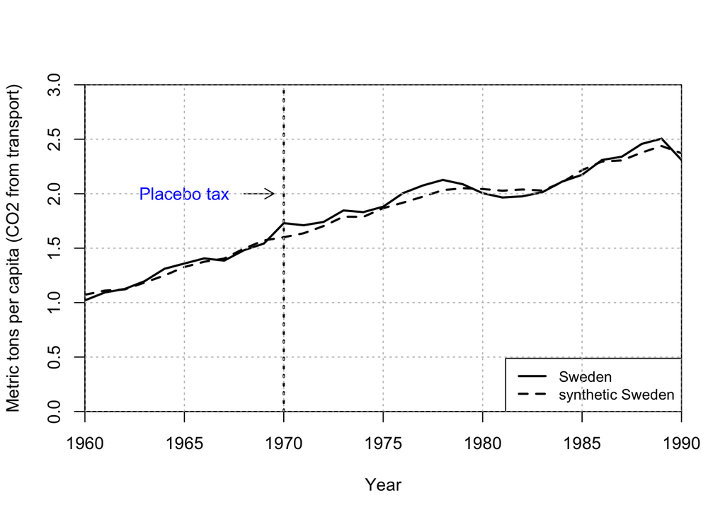

```r
#png("placebo_1970.png", width = 800, height = 600)  # Adjust width and height as needed

 path.plot(synth.res = synth.out,
           dataprep.res = dataprep.out,
           Ylab = "Metric tons per capita (CO2 from transport)",
           Xlab = "Year",
           Ylim = c(0,3),
           Legend = c("Sweden","synthetic Sweden"),
           Legend.position = "bottomright"
           )

# Add line
abline(v=1970,lty="dotted",lwd=2)
arrows(1968,2.0,1969.5,2.0,col="black",length=.1)
Cex.set <- 1
text(1965,2.0,"Placebo tax",col="blue",cex=Cex.set)
grid(lty = "dotted", col = "gray")
```

```r
#dev.off()
```

### Placebo in-space tests

For the in-space placebo test, the treatment is iteratively reassigned to every country in the donor pool, again using the synthetic control method to construct synthetic counterparts.

```r
store <- matrix(NA,length(1960:2005),15)
colnames(store) <- unique(carbontax$country)

#added additional years of co2_transport_capita in special predictors to increase emphasis for the outcome of interest(co2 from trans)

# run placebo test
for(iter in 1:15)
 {
 dataprep.out <-
              dataprep(foo = carbontax,
                       predictors = c("GDP_per_capita" , "gas_cons_capita" , "vehicles_capita" ,
                                      "urban_pop") ,
                       predictors.op = "mean" ,
                       time.predictors.prior = 1980:1989 ,
                       special.predictors = list(
                         list("CO2_transport_capita" , 1989 , "mean"),
                list("CO2_transport_capita" , 1980 , "mean") ,
                list("CO2_transport_capita" , 1975 , "mean"),
                list("CO2_transport_capita" , 1970 , "mean"),
                list("CO2_transport_capita" , 1965 , "mean")

                      ),
                       dependent = "CO2_transport_capita",
                       unit.variable = "Countryno",
                       unit.names.variable = "country",
                       time.variable = "year",
                       treatment.identifier = iter,
                       controls.identifier = c(1:15)[-iter],
                       time.optimize.ssr = 1960:1989,
                       time.plot = 1960:2005
                       )



# run synth
synth.out <- synth(
                   data.prep.obj = dataprep.out,
                   method = "BFGS"
                   )

# store gaps
store[,iter] <- dataprep.out$Y1plot - (dataprep.out$Y0plot %*% synth.out$solution.w)
}
```

```
##
## X1, X0, Z1, Z0 all come directly from dataprep object.
##
##
## ****************
##  searching for synthetic control unit
##
##
## ****************
## ****************
## ****************
##
## MSPE (LOSS V): 0.02016177
##
## solution.v:
##  0.001057176 0.03914691 0.06152464 0.003994545 0.2479173 0.06332096 0.2846075 0.1669109 0.13152
##
## solution.w:
##  0.04491148 0.1160488 1.0275e-06 1.05898e-05 0.08684721 0.4677828 3.7361e-06 0.0002606659 2.477e-07 1.2378e-06 1.7868e-06 3.10725e-05 6.21382e-05 0.2840372
##
##
## X1, X0, Z1, Z0 all come directly from dataprep object.
##
##
## ****************
##  searching for synthetic control unit
##
##
## ****************
## ****************
## ****************
##
## MSPE (LOSS V): 0.001907305
##
## solution.v:
##  0.0004420092 0.004327276 0.02873972 0.0002098728 0.1298953 0.1109401 0.3584534 0.2041493 0.162843
##
## solution.w:
##  0.01867822 0.0005186198 0.02772954 0.2741433 0.240193 7.35979e-05 0.1144359 0.0758811 2.24463e-05 1.02775e-05 0.0001654379 0.2476926 1.3976e-06 0.0004545598
##
```

[output cut: 244 more lines]

```
## ****************
##  searching for synthetic control unit
##
##
## ****************
## ****************
## ****************
##
## MSPE (LOSS V): 1.085804
##
## solution.v:
##  0.01320564 0.04654995 0.01242976 0.002029781 0.1630591 0.03523636 0.3429541 0.2374461 0.1470892
##
## solution.w:
##  6.6e-09 1.9e-09 1 2.3e-09 1.9e-09 1.1e-09 2.7e-09 1.5e-09 3.3e-09 1.3e-09 1e-09 1.4e-09 2.9e-09 2.2e-09
```

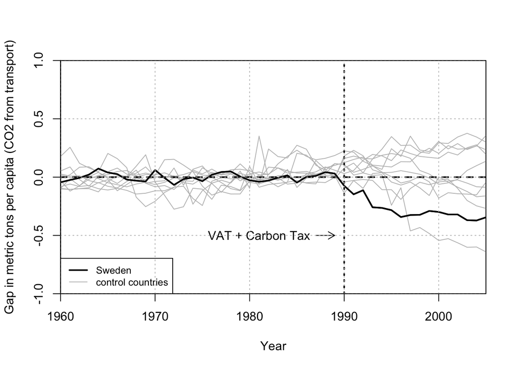

```r
# now do figure
data <- store
rownames(data) <- 1960:2005

# Set bounds in gaps data
gap.start     <- 1
gap.end       <- nrow(data)
years         <- 1960:2005
gap.end.pre  <- which(rownames(data)=="1989")

#  MSPE Pre-Treatment
mse        <- apply(data[ gap.start:gap.end.pre,]^2,2,mean)
sweden.mse <- as.numeric(mse[13])
# Exclude states with 20 times higher MSPE than Sweden (to include all countries, set value to 1000)
data <- data[,mse<20*sweden.mse]
Cex.set <- 1

# Plot
plot(years,data[gap.start:gap.end,which(colnames(data)=="Sweden")],
     ylim=c(-1,1),xlab="Year",
     xlim=c(1960,2005),ylab="Gap in metric tons per capita (CO2 from transport)",
     type="l",lwd=2,col="black",
     xaxs="i",yaxs="i")

# Add lines for control states
for (i in 1:ncol(data)) { lines(years,data[gap.start:gap.end,i],col="gray") }

## Add Sweden Line
lines(years,data[gap.start:gap.end,which(colnames(data)=="Sweden")],lwd=2,col="black")

# Add grid
abline(v=1990,lty="dotted",lwd=2)
abline(h=0,lty="dashed",lwd=2)
legend("bottomleft",legend=c("Sweden","control countries"),
lty=c(1,1),col=c("black","gray"),lwd=c(2,1),cex=.8)
arrows(1987,-0.5,1989,-0.5,col="black",length=.1)
text(1981,-0.5,"VAT + Carbon Tax",cex=Cex.set)
grid(lty = "dotted", col = "gray")
abline(v=1960)
abline(v=2005)
abline(h=-1)
abline(h=1)
```

A better inferential method is to look at the ratio of posttreatment MSPE to pretreatment MSPE (Abadie et al. 2010), with the assumption that a large ratio is indicative of a true causal effect from treatment. With the ratio test we do not have to discard countries based on an arbitrarily chosen cutoff rule, and thus the ratio test is advantageous when you have a small number of control units.

### Ratio Test: Ratios of Post-Treatment MSPE to Pre-Treatment MSPE

```r
 dataprep.out <-
              dataprep(foo = carbontax,
                       predictors = c("GDP_per_capita" , "gas_cons_capita" , "vehicles_capita" ,
                                      "urban_pop") ,
                       predictors.op = "mean" ,
                       time.predictors.prior = 1980:1989 ,
                       special.predictors = list(
                         list("CO2_transport_capita" , 1989 , "mean"),
                         list("CO2_transport_capita" , 1980 , "mean"),
                         list("CO2_transport_capita" , 1970 , "mean")
                                                ),
                       dependent = "CO2_transport_capita",
                       unit.variable = "Countryno",
                       unit.names.variable = "country",
                       time.variable = "year",
                       treatment.identifier = 13,
                       controls.identifier = c(1:12, 14:15),
                       time.optimize.ssr = 1960:1989,
                       time.plot = 1960:2005
                       )

 synth.out <- synth(data.prep.obj = dataprep.out,
                    method = "All")
```

```
##
## X1, X0, Z1, Z0 all come directly from dataprep object.
##
##
## ****************
##  searching for synthetic control unit
##
##
## ****************
## ****************
## ****************
##
## MSPE (LOSS V): 0.001222443
##
## solution.v:
##  0.2188493 0.009719276 0.07826532 0.2126716 0.1832151 0.2838626 0.01341685
##
## solution.w:
##  0.0007695733 0.1954709 5.61912e-05 0.3842992 0.0003365576 0.09042864 0.001226448 0.0003818197 0.1765464 0.0006891624 0.0003987502 0.0004105377 0.06109071 0.08789508
```

```r
 gaps <- dataprep.out$Y1plot - (dataprep.out$Y0plot %*% synth.out$solution.w)
 mspepost <- mean((gaps[31:46, 1])^2)
 mspepre <- mean((gaps[1:30, 1])^2)
 mspepost/mspepre
```

```
## [1] 73.272
```

### Leave-One-Out: Distribution of the Synthetic Control for Sweden

```r
# Example: eliminating New Zealand

 dataprep.out <-
              dataprep(foo = carbontax,
                       predictors = c("GDP_per_capita" , "gas_cons_capita" , "vehicles_capita" ,
                                      "urban_pop") ,
                       predictors.op = "mean" ,
                       time.predictors.prior = 1980:1989 ,
                       special.predictors = list(
                         list("CO2_transport_capita" , 1989 , "mean"),
                         list("CO2_transport_capita" , 1980 , "mean"),
                         list("CO2_transport_capita" , 1970 , "mean")
                                                ),
                       dependent = "CO2_transport_capita",
                       unit.variable = "Countryno",
                       unit.names.variable = "country",
                       time.variable = "year",
                       treatment.identifier = 13,
                       controls.identifier = c(1:8, 10:12, 14:15),
                       time.optimize.ssr = 1960:1989,
                       time.plot = 1960:2005
                       )

synth.out <- synth(data.prep.obj = dataprep.out,
                    method = "All")
```

```
##
## X1, X0, Z1, Z0 all come directly from dataprep object.
##
##
## ****************
##  searching for synthetic control unit
##
##
## ****************
## ****************
## ****************
##
## MSPE (LOSS V): 0.001479115
##
## solution.v:
##  0.005582893 0.009475485 0.003215815 0.3597227 0.1239453 0.4052939 0.09276386
##
## solution.w:
##  0.002068293 0.3138772 0.0003571681 0.373265 0.004572283 0.05694911 0.001172922 0.004518083 0.01316495 0.01622783 0.01013312 0.08759249 0.1161016
```

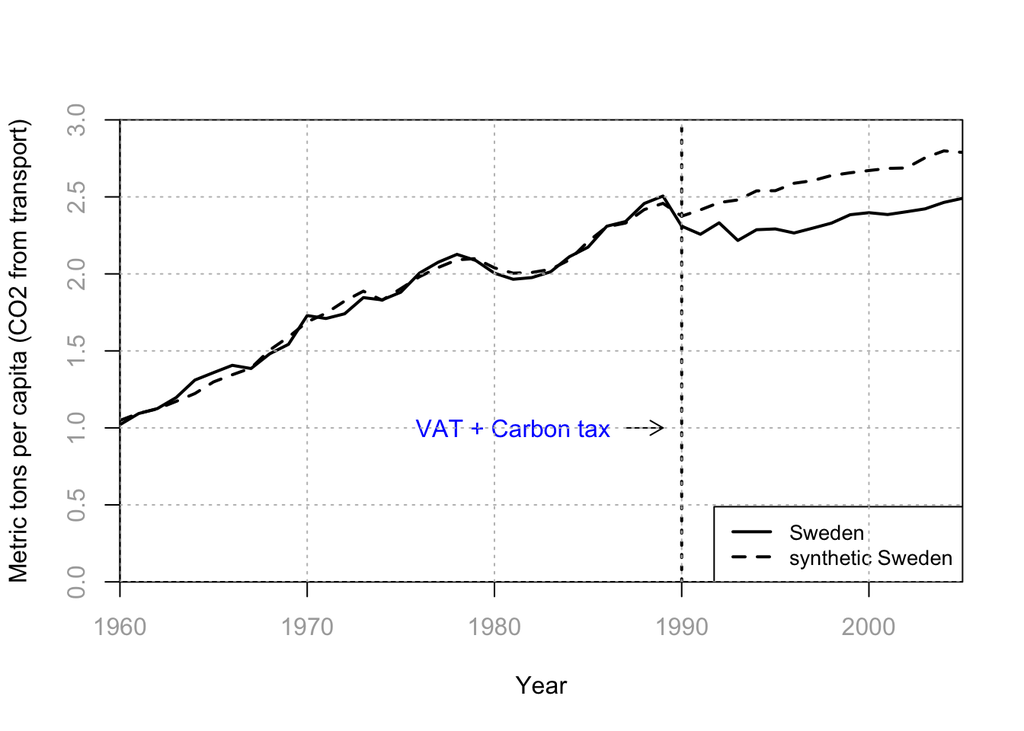

```r
par(col.axis = "darkgray", col.lab = "black", col.main = "black", col.sub = "black")  # Set axis, labels, title, and subtitle color to black
par(font.main = 1, font.axis = 1, font.lab = 1, font.sub = 1)  # Set font style to bold
par(bg = "white")
  path.plot(synth.res = synth.out,
           dataprep.res = dataprep.out,
           Ylab = "Metric tons per capita (CO2 from transport)",
           Xlab = "Year",
           Ylim = c(0,3),
           Legend = c("Sweden","synthetic Sweden"),
           Legend.position = "bottomright"
           )
# Add line
abline(v=1990,lty="dotted",lwd=2)
arrows(1987,1.0,1989,1.0,col="black",length=.1)
Cex.set <- 1
text(1981,1.0,"VAT + Carbon tax",col="blue",cex=Cex.set)
grid(lty = "dotted", col = "gray")
```

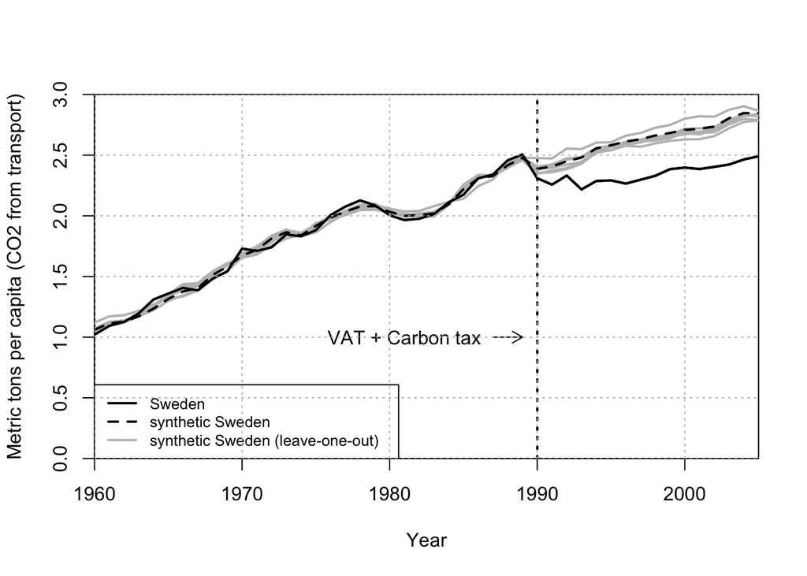

```r
leaveoneout <- read.dta('leave_one_out_data.dta')
attach(leaveoneout)

plot(Year[1:46], sweden, type="l", lwd=2, col="black", ylim=c(0,3.0), xlab="Year", ylab="Metric tons per capita (CO2 from transport)", xaxs="i",yaxs="i" )
abline(v=1990,lty="dotted",lwd=2)
legend("bottomleft",legend=c("Sweden","synthetic Sweden", "synthetic Sweden (leave-one-out)   "),
lty=c(1,2,1),col=c("black","black","gray"),lwd=c(2,2,2),cex=0.8)
lines(Year, excl_belgium, lty="solid" ,lwd=2, col="gray")
lines(Year, excl_denmark, lty="solid",lwd=2, col="gray")
lines(Year, excl_greece, lty="solid" ,lwd=2, col="gray")
lines(Year, excl_newzealand, lty="solid" ,lwd=2, col="gray")
lines(Year, excl_switzerland, lty="solid" ,lwd=2, col="gray")
lines(Year, excl_unitedstates, lty="solid" ,lwd=2, col="gray")
lines(Year, synth_sweden, lty="dashed" , lwd=2, col="black")
lines(Year, sweden, lty="solid" , lwd=2, col="black")
arrows(1987,1.0,1989,1.0,col="black",length=.1)
Cex.set <- 1
text(1981,1.0,"VAT + Carbon tax",cex=Cex.set)
grid(lty = "dotted", col = "gray")
```

### possible confounder

A common argument against carbon taxation is that it will hurt economic growth. We also find that there is clear evidence of a link between GDP growth and growth in CO2 emissions. This could mean that the introduction of the carbon tax reduced the level of GDP in Sweden post-treatment, and that this is the actual driver behind the emission reductions.

Or, alternatively, this can be treated as an exogenous variable in the form of financial and economic crisis in the early 1990s which is reducing the emissions.

To counter this claim we need to analyse the reduction in gdp per capita with synthetic sweden.

```r
descriptive <- read.dta('descriptive_data.dta')
attach(descriptive)
descriptive[1:46, 1:14]
```

```
##    year Real_VAT Real_Energytax Real_Carbontax Real_Gasoline_Price
## 1  1960 0.000000       4.128581      0.0000000            7.451586
## 2  1961 0.000000       4.125493      0.0000000            7.170499
## 3  1962 0.000000       3.955619      0.0000000            7.440332
## 4  1963 0.000000       3.842602      0.0000000            6.953279
## 5  1964 0.000000       3.715223      0.0000000            6.634326
## 6  1965 0.000000       3.960576      0.0000000            6.572871
## 7  1966 0.000000       4.462529      0.0000000            6.782917
## 8  1967 0.000000       4.325203      0.0000000            6.753387
## 9  1968 0.000000       4.244734      0.0000000            6.553274
## 10 1969 0.000000       4.129493      0.0000000            6.013121
## 11 1970 0.000000       4.002710      0.0000000            5.630931
## 12 1971 0.000000       4.286367      0.0000000            6.051341
## 13 1972 0.000000       4.047350      0.0000000            5.713906
## 14 1973 0.000000       3.960870      0.0000000            5.801837
```

[output cut: 126 more lines]

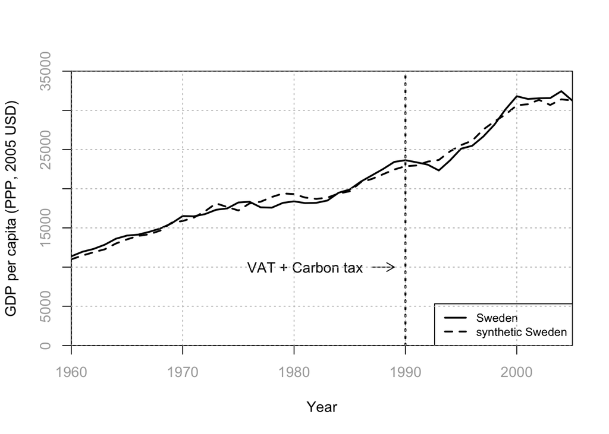

```r
par(col.axis = "darkgray", col.lab = "black", col.main = "black", col.sub = "black")  # Set axis, labels, title, and subtitle color to black
par(font.main = 1, font.axis = 1, font.lab = 1, font.sub = 1)  # Set font style to bold
par(bg = "white")
plot(year[1:46], GDP_Sweden, type="l", lwd=2, col="black", ylim=c(0,35000), xlab="Year", ylab="GDP per capita (PPP, 2005 USD)", xaxs="i",yaxs="i" )
abline(v=1990,lty="dotted",lwd=2)
legend("bottomright",legend=c("Sweden","synthetic Sweden"),
lty=c(1:2),col=c("black","black"),lwd=c(2,2),cex=.8)
lines(year, GDP_Synthetic_Sweden, lty="dashed" , lwd=2, col="black")
abline(v=1990,lty="dotted",lwd=2)
arrows(1987,10000,1989,10000,col="black",length=.1)
Cex.set <- 1
text(1981,10000,"VAT + Carbon tax",cex=Cex.set)
grid(lty = "dotted", col = "gray")
```

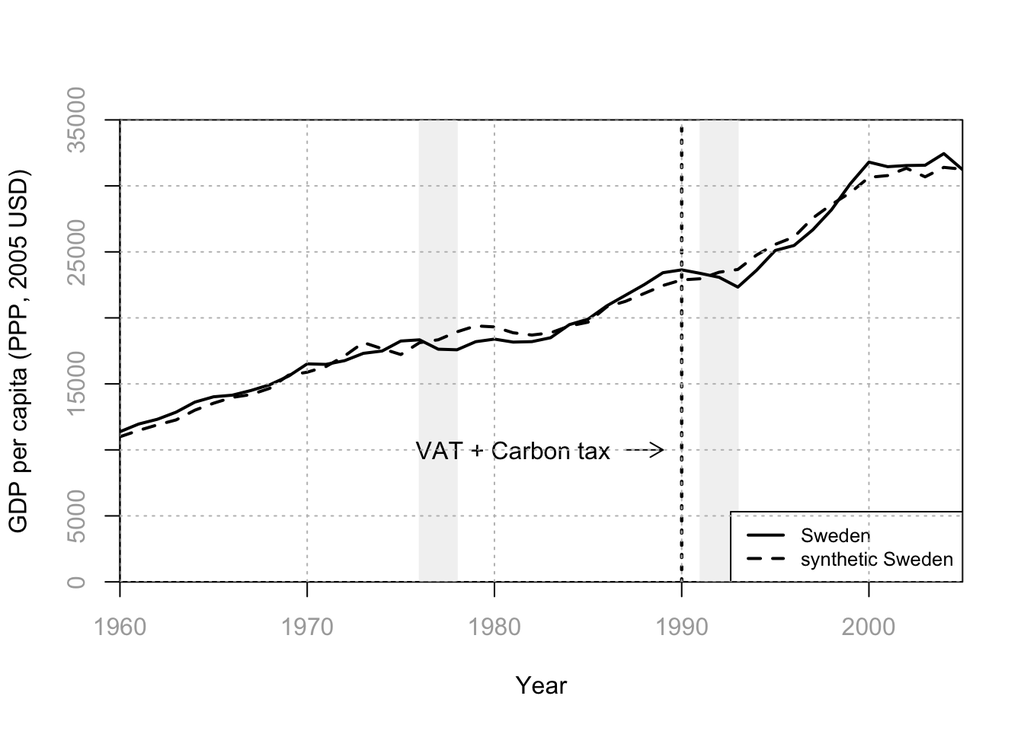

```r
#Adding shaded areas for the two main recessions

plot(year[1:46], GDP_Sweden, type="l", lwd=2, col="white", ylim=c(0,35000), xlab="Year", ylab="GDP per capita (PPP, 2005 USD)", xaxs="i",yaxs="i" )
rect(1991, 100, 1993, 34900,
     border = "gray95", col = "gray95")
rect(1976, 100, 1978, 34900,
     border = "gray95", col = "gray95")
abline(v=1990,lty="dotted",lwd=2)
lines(year, GDP_Sweden, lty="solid", lwd=2, col="black")
legend("bottomright",legend=c("Sweden","synthetic Sweden"),
lty=c(1:2),col=c("black","black"),lwd=c(2,2),cex=.8)
lines(year, GDP_Synthetic_Sweden, lty="dashed" , lwd=2, col="black")
abline(v=1990,lty="dotted",lwd=2)
arrows(1987,10000,1989,10000,col="black",length=.1)
Cex.set <- 1
text(1981,10000,"VAT + Carbon tax",cex=Cex.set)
grid(lty = "dotted", col = "gray")
```

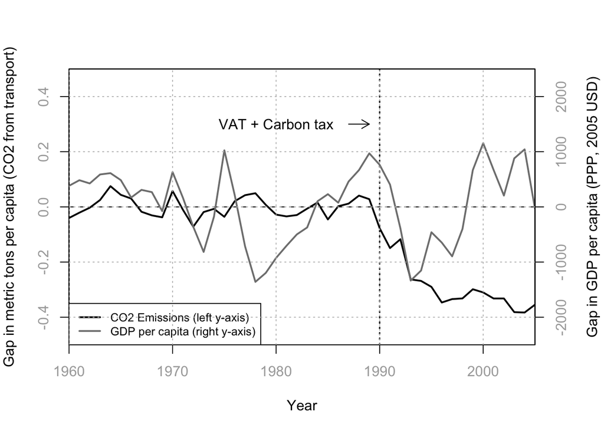

```r
par(col.axis = "darkgray", col.lab = "black", col.main = "black", col.sub = "black")  # Set axis, labels, title, and subtitle color to black
par(font.main = 1, font.axis = 1, font.lab = 1, font.sub = 1)  # Set font style to bold
par(bg = "white")
par(mar = c(5, 4, 4, 4))
plot(year, gap_CO2_emissions_transp, type="l", lwd=2, col="black", ylim=c(-0.50,0.50), xlab="Year" , ylab="Gap in metric tons per capita (CO2 from transport)", xaxs="i",yaxs="i")
abline(v=1990,lty="dotted",lwd=1.5)
abline(h = 0, col = "black", lty = "dashed", lwd = 1)
par(new = TRUE)
plot(year, gap_GDP, type="l" , lwd=2, col="gray50", ylim=c(-2500,2500),
 xlab="", ylab="", xaxt="n", yaxt="n", xaxs="i", yaxs="i")
 axis(side=4)
 mtext("Gap in GDP per capita (PPP, 2005 USD)", side = 4, line = 2.8)
legend("bottomleft",legend=c("CO2 Emissions (left y-axis)" ,"GDP per capita (right y-axis)"),
lty=c(1,1),col=c("black","gray50"),lwd=c(2,2),cex=0.8)
arrows(1987,1500,1989,1500,col="black",length=.1)
Cex.set <- 1
text(1980,1500,"VAT + Carbon tax",cex=Cex.set)
grid(lty = "dotted", col = "gray")
```

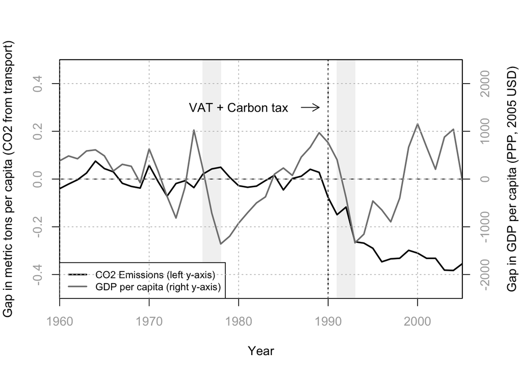

```r
#Adding shaded areas for the two main recessions
par(mar = c(5, 4, 4, 4))
plot(year, gap_CO2_emissions_transp, type="l", lwd=2, col="white", ylim=c(-0.50,0.50), xlab="Year" , ylab="Gap in metric tons per capita (CO2 from transport)", xaxs="i",yaxs="i")
rect(1991, -0.496, 1993, 0.496,
     border = "gray95", col = "gray95")
rect(1976, -0.496, 1978, 0.496,
     border = "gray95", col = "gray95")
abline(v=1990,lty="dotted",lwd=1.5)
abline(h = 0, col = "black", lty = "dashed", lwd = 1)
lines(year, gap_CO2_emissions_transp, lty="solid", lwd=2, col="black")
par(new = TRUE)
plot(year, gap_GDP, type="l" , lwd=2, col="gray50", ylim=c(-2500,2500),
 xlab="", ylab="", xaxt="n", yaxt="n", xaxs="i", yaxs="i")
 axis(side=4)
 mtext("Gap in GDP per capita (PPP, 2005 USD)", side = 4, line = 2.8)
legend("bottomleft",legend=c("CO2 Emissions (left y-axis)" ,"GDP per capita (right y-axis)"),
lty=c(1,1),col=c("black","gray50"),lwd=c(2,2),cex=0.8)
arrows(1987,1500,1989,1500,col="black",length=.1)
Cex.set <- 1
text(1980,1500,"VAT + Carbon tax",cex=Cex.set)
grid(lty = "dotted", col = "gray")
```

Figures show that GDP per capita in Sweden along with Synthetic Sweden track each other quite well during the 30 years before and 16 years after treatment. We can conclude that there is no indication that the domestic recession in 1991–1993 is driving emissions posttreatment and there is no observable (long-term) negative effect on GDP from the carbon tax.

###Disentangling the Carbon Tax and VAT

For the purpose of disentangling the VAT and carbon tax effect on transport emissions we analyze annual time-series data of the consumption and real price of gasoline in Sweden from 1970-2011. The article already decomposes the retail price of gasoline into its carbon tax-exclusive price component and the carbon tax. VAT is a constant and a multiplier so it means that it is perfectly correlated with all the price components and not treated separately. We regress vector of control variables GDP per capita, urbanization, the unemployment rate and a time trend, both parts of the gasoline price and dummy of 1 for years that are from 1991 on the log gasoline consumption per capita. We create different models that control for different variables.

Furthermore we are also concerned about the possible omitted variables and the endogeneity of gasoline prices (if gasoline consumption affects the gasoline prices). In reality we can argue that this effect is not a risk as Sweden is a small country and its demand does not influence the prices of gasoline. But to make sure that we are getting the right results, we include an instrumental variable in our model. We use 2-stage least squares regression and use the energy tax rate and the brend crude oil price. We can argue for the instrument validity of energy tax rate: - instrument relevance: crude oil price is correlated with gas prices as well as energy tax is directly a part of gas prices. - instrument exogeneity:energy tax rates are changes infrequently and should not influence the consumption of gasoline directly.

We run different models and compare the estimates. We observe that the estimated coefficients in column 4,5 and 6 are almost identical, thus eliminating the likely problem of endogeneity.The results of OLS regression of our log-linear model show that one-unit change to the carbon tax is associated with a change in gasoline consumption of 18.6 % and one unit change of the tax-exclusive price is associated with 6% change in gasoline consumption. Therefore we can observe that carbon tax elasticity is around 3.1-4.5 times larger thant the corresponding price elasticity. We can calculate the price elasticities as E = dy/dx * (X/Y) = b X at the sample mean. The price elasticity of demand is calculated as being -0.51 and the carbon tax elasticity is -1.57.

```r
library(haven)
disentangling <- read_dta("disentangling_regression_data.dta")


model1 <- lm(log_gas_cons ~ real_carbontaxexclusive_with_vat + real_carbontax_with_vat + d_carbontax + t, data=disentangling)
model2 <- update(model1, . ~ . + real_gdp_cap_1000)
model3 <- update(model2, . ~ . + urban_pop)
model4 <- update(model3, . ~ . + unemploymentrate)

iv_model1 <- ivreg(log_gas_cons ~ real_carbontaxexclusive_with_vat + real_carbontax_with_vat + d_carbontax + t + real_gdp_cap_1000 + urban_pop + unemploymentrate | real_energytax_with_vat + real_carbontax_with_vat + d_carbontax + t + real_gdp_cap_1000 + urban_pop + unemploymentrate, data=disentangling)

iv_model2 <- ivreg(log_gas_cons ~ real_carbontaxexclusive_with_vat + real_carbontax_with_vat + d_carbontax + t + real_gdp_cap_1000 + urban_pop + unemploymentrate | real_oil_price_sek + real_carbontax_with_vat + d_carbontax + t + real_gdp_cap_1000 + urban_pop + unemploymentrate, data=disentangling)
```

```r
stargazer(model1, model2, model3, model4, iv_model1, iv_model2, type = "text",
          header = FALSE,
          title = "Regression Results",
          model.names = FALSE,
          ci = TRUE,
          omit.stat = "all",
          add.lines = list(c("Observations", nrow(disentangling), nrow(disentangling), nrow(disentangling), nrow(disentangling), nrow(disentangling), nrow(disentangling))))
```

```
##
## Regression Results
## =========================================================================================================================================
##                                                                            Dependent variable:
##                                  --------------------------------------------------------------------------------------------------------
##                                                                                log_gas_cons
##                                        (1)              (2)              (3)               (4)               (5)               (6)
## -----------------------------------------------------------------------------------------------------------------------------------------
## real_carbontaxexclusive_with_vat    -0.057***        -0.060***        -0.061***         -0.060***          -0.062           -0.064***
##                                  (-0.089, -0.026) (-0.092, -0.028) (-0.095, -0.027) (-0.093, -0.028)   (-0.154, 0.030)  (-0.101, -0.027)
##
## real_carbontax_with_vat             -0.260***        -0.232***        -0.234***         -0.186***         -0.186***         -0.186***
##                                  (-0.314, -0.206) (-0.315, -0.150) (-0.318, -0.149) (-0.277, -0.094)  (-0.277, -0.094)  (-0.277, -0.094)
##
## d_carbontax                          0.109**           0.060            0.063             0.100             0.098             0.095
##                                   (0.011, 0.206)  (-0.086, 0.207)  (-0.086, 0.213)   (-0.047, 0.246)   (-0.089, 0.284)   (-0.054, 0.244)
##
## t                                    0.021***         0.025***         0.024***         0.034***          0.034***          0.034***
##                                   (0.015, 0.027)   (0.013, 0.037)   (0.011, 0.038)   (0.018, 0.050)    (0.016, 0.052)    (0.018, 0.050)
##
## real_gdp_cap_1000                                      -0.001           -0.001          -0.004**          -0.004**          -0.004**
##                                                   (-0.004, 0.001)  (-0.004, 0.001)  (-0.007, -0.0003) (-0.007, -0.0002) (-0.007, -0.0003)
##
## urban_pop                                                               0.013             0.030             0.031             0.033
##                                                                    (-0.075, 0.100)   (-0.055, 0.115)   (-0.077, 0.139)   (-0.054, 0.119)
##
## unemploymentrate                                                                        -0.024**          -0.024**          -0.024**
##                                                                                     (-0.047, -0.002)  (-0.047, -0.002)  (-0.047, -0.002)
##
## Constant                             6.228***         6.407***          5.372             4.407             4.313             4.198
##                                   (6.039, 6.417)   (5.960, 6.853)  (-1.803, 12.547) (-2.490, 11.304)  (-4.107, 12.733)  (-2.785, 11.181)
##
## -----------------------------------------------------------------------------------------------------------------------------------------
## Observations                            42               42               42               42                42                42
## =========================================================================================================================================
## Note:                                                                                                         *p<0.1; **p<0.05; ***p<0.01
```

We then create predictions from the estimated full model (model4) and disentangle the effect of the carbon tax on gasoline consumption. We could also calculate the effect on emissions from the effect of VAT and carbon tax as in the article, but we omit this part due to the missing empirical data on diesel consumption and (weighted) emissions factors. We do this by predicting gasoline consumption using the full model, without the carbon tax and gasoline consumption without the carbon tax and without the VAT. We then plot the data on the line plot and can observe the contributions of the VAT and carbon tax to the reduction of the consumption of gas per capita.

```r
#creating the predictions

#Predict the full model
disentangling$yhat <- predict(model4, newdata = disentangling)

# Predict without the carbon tax
disentangling_no_carb <- disentangling %>%
  mutate(d_carbontax = 0, real_carbontax_with_vat = 0)

disentangling_no_carb$yhat_nocarb <- predict(model4, newdata = disentangling_no_carb)

# Predict without the carbon tax and without VAT
disentangling_no_carb_novat <- disentangling %>%
  mutate(real_carbontaxexclusive_with_vat = real_carbontaxexclusive, d_carbontax = 0, real_carbontax_with_vat = 0)
disentangling_no_carb_novat$yhat_nocarb_novat <- predict(model4, newdata = disentangling_no_carb_novat)

# We decide not to convert the data to emissions, but rather keep it and see how the consumption of the gas consumption changes

# To create a summary table of the original and predicted values
summary_table <- data.frame(
  year = disentangling$year,
  LogGasCons = disentangling$log_gas_cons,
  CarbonTaxandVAT = disentangling$yhat,
  NoCarbonTaxWithVAT = disentangling_no_carb$yhat_nocarb,
  NoCarbonTaxNoVAT = disentangling_no_carb_novat$yhat_nocarb_novat
)

# Assuming you want to display the first few rows of the summary table
head(summary_table)
```

```
##   year LogGasCons CarbonTaxandVAT NoCarbonTaxWithVAT NoCarbonTaxNoVAT
## 1 1970   5.838571        5.901383           5.901383         5.901383
## 2 1971   5.854251        5.898209           5.898209         5.898209
## 3 1972   5.890871        5.939009           5.939009         5.939009
## 4 1973   5.945398        5.956679           5.956679         5.956679
## 5 1974   5.873227        5.944941           5.944941         5.944941
## 6 1975   5.982583        5.978661           5.978661         5.978661
```

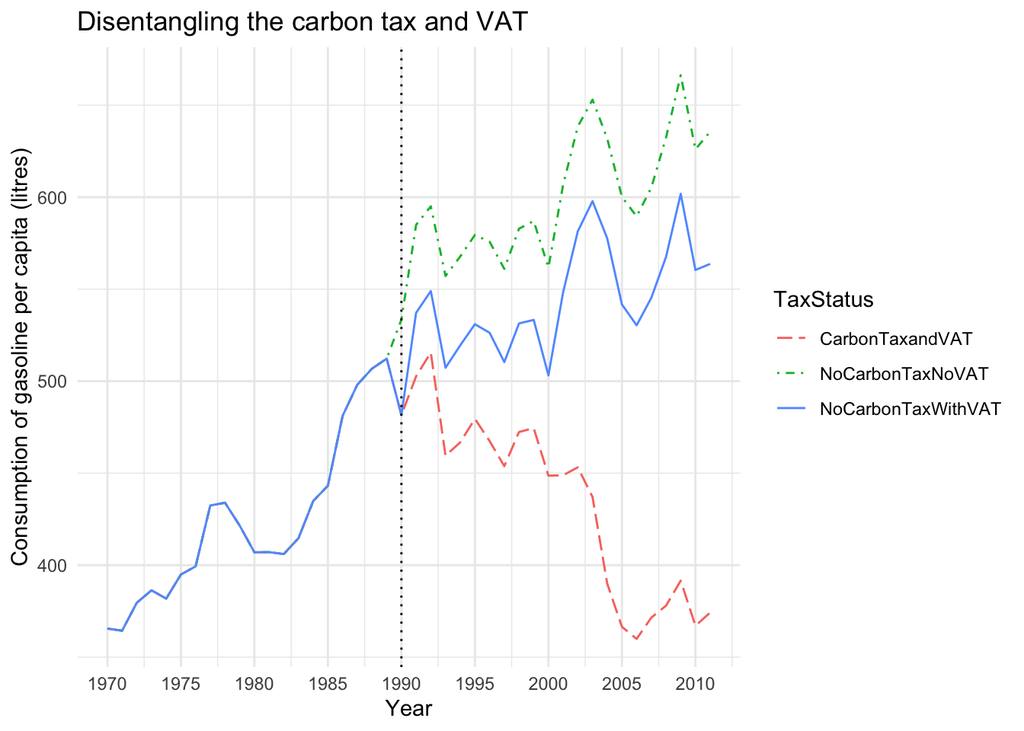

```r
long_summary_table <- pivot_longer(summary_table, cols = c(CarbonTaxandVAT, NoCarbonTaxWithVAT, NoCarbonTaxNoVAT),
                        names_to = "TaxStatus", values_to = "Predictions")
long_summary_table <- long_summary_table %>% mutate(gasconspredictions=exp(Predictions))

ggplot(long_summary_table, aes(x = year, y = gasconspredictions, color = TaxStatus, group = TaxStatus)) +
  geom_line(aes(linetype = TaxStatus)) +
  scale_linetype_manual(values = c("longdash", "dotdash", "solid")) + # Custom line types
  labs(x = "Year", y = "Consumption of gasoline per capita (litres)", title="Disentangling the carbon tax and VAT") +
  theme_minimal() +
  geom_vline(xintercept = 1990, linetype = "dotted") + # Add vertical line for 1990
  scale_x_continuous(breaks = seq(min(long_summary_table$year), max(long_summary_table$year), by = 5))
```

```r
ggsave('figure13.jpg')
```

## Conclusion

In this notebook we used the replication R code and the code from Stata to reproduce the results. During the course of recreating the codes we learned about how to apply the synthetic-control method and how to rigorously test it. Furthermore we learned more about how to apply different econometric and machine learning tools to observe the economic effects of different policies or tax rises.